# Homework 3: Some of my Best Friends are Zombies

[figure not shown]

Disco Zombie from Plants v. Zombies

## Background

In order to play with same data, we first need to load the data.

```r
f<-curl(url = "https://raw.githubusercontent.com/fuzzyatelin/fuzzyatelin.github.io/master/AN588_Fall23/zombies.csv")
z<-read.csv(f, header=TRUE, sep = ",", stringsAsFactors = TRUE)
```

What we’ve loaded is a dataset including the first name, last name, and gender of the entire population of 1000 people who have survived the zombie apocalypse and are now ekeing out an existence somewhere on the East Coast, along with several other variables (height, weight, age, number of years of education, number of zombies they have killed, and college major).

## Question 1

Calculate the population mean and standard deviation for each quantitative random variable (height, weight, age, number of zombies killed, and years of education).

We’re going to calculate means first. Mean of height:

```r
h<-z$height
mean(h)
```

```
## [1] 67.6301
```

Mean of weight:

```r
w<-z$weight
mean(w)
```

```
## [1] 143.9075
```

Mean of age:

```r
a<-z$age
mean(a)
```

```
## [1] 20.04696
```

Mean number of zombies killed:

```r
zk<-z$zombies_killed
mean(zk)
```

```
## [1] 2.992
```

Mean years of education:

```r
e<-z$years_of_education
mean(e)
```

```
## [1] 2.996
```

For standard deviation, we’re going to write an equation. SD=square root of variance variance=sum of squares/n sum of squares=the sum of the squared deviations of a set of values from the mean So, going to start with a sum of squares equation and build up from there.

```r
ss<-function(x){
  sum(x^2) - (sum(x))^2/length(x)
}
```

Now, variance equation:

```r
v<-function(x){
  ss(x)/length(x)
}
```

Finally, standard deviation equation

```r
sdf<-function(x){
  sqrt(v(x))
}
```

Now, let’s calculate the standard deviations. SD of height:

```r
sdf(h)
```

```
## [1] 4.30797
```

SD of weight:

```r
sdf(w)
```

```
## [1] 18.39186
```

SD of age:

```r
sdf(a)
```

```
## [1] 2.963583
```

SD of number of zombies killed:

```r
sdf(zk)
```

```
## [1] 1.747551
```

SD of number of years of education:

```r
sdf(e)
```

```
## [1] 1.675704
```

## Question 2

Use {ggplot} to make boxplots of each of these variables by gender.

Age boxplot:

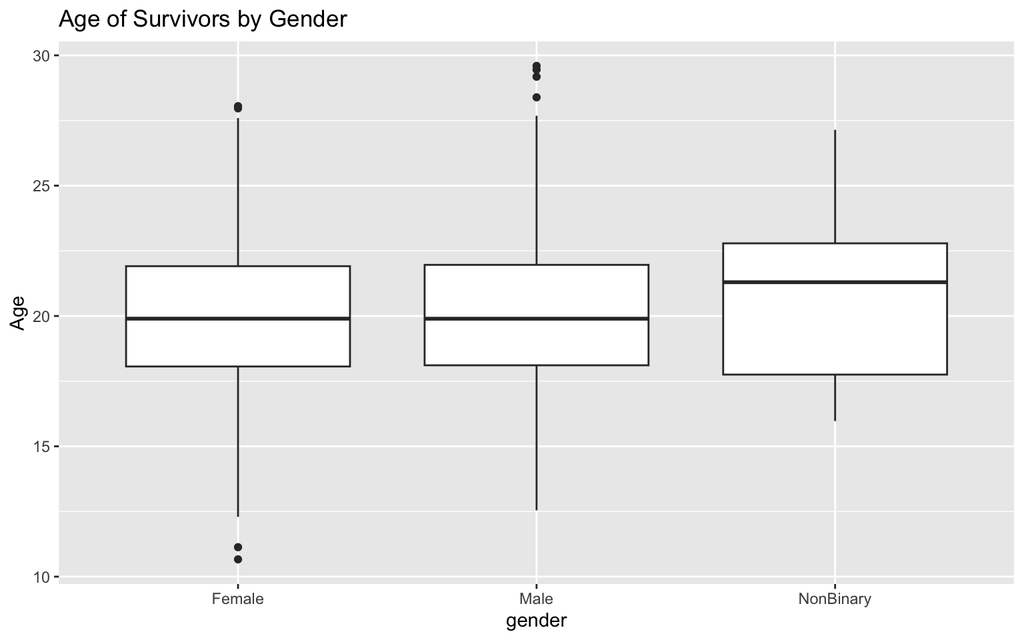

```r
ggplot(data = z) + geom_boxplot(aes(x = gender, y = a)) + ylab("Age") + ggtitle("Age of Survivors by Gender")
```

Height boxplot:

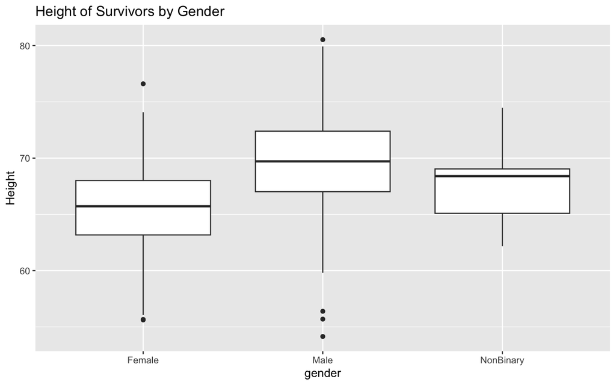

```r
ggplot(data = z) + geom_boxplot(aes(x = gender, y = h)) + ylab("Height") + ggtitle("Height of Survivors by Gender")
```

Weight boxplot:

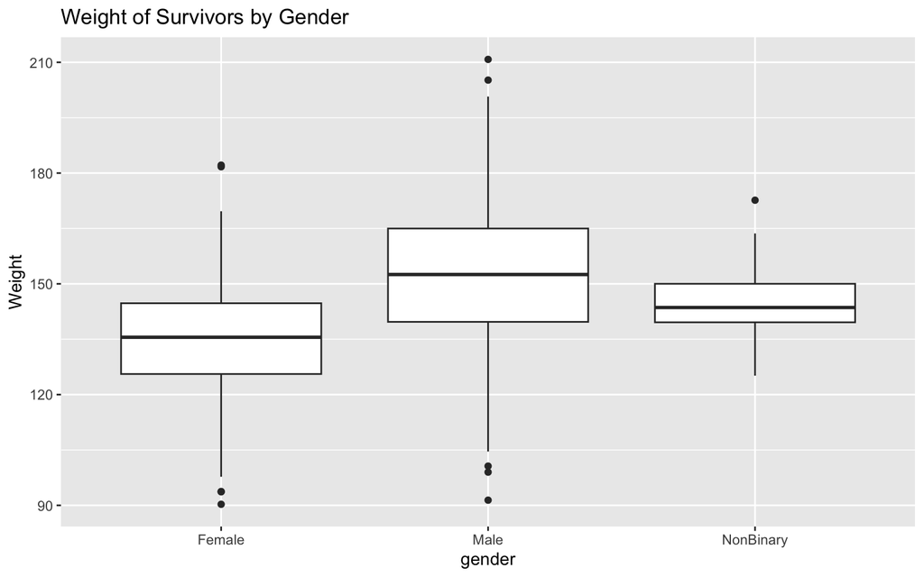

```r
ggplot(data = z) + geom_boxplot(aes(x = gender, y = w)) + ylab("Weight") + ggtitle("Weight of Survivors by Gender")
```

Number of zombies killed boxplot:

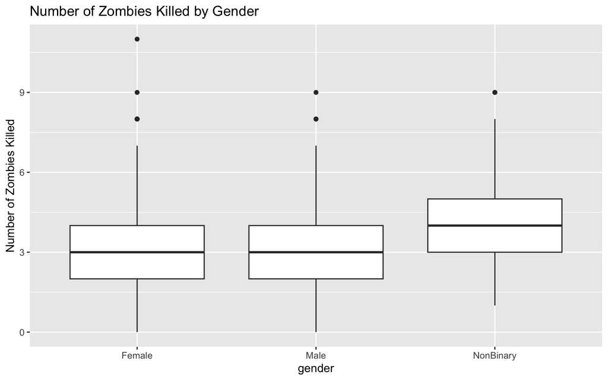

```r
ggplot(data = z) + geom_boxplot(aes(x = gender, y = zk)) + ylab("Number of Zombies Killed") + ggtitle("Number of Zombies Killed by Gender")
```

Years of education boxplot:

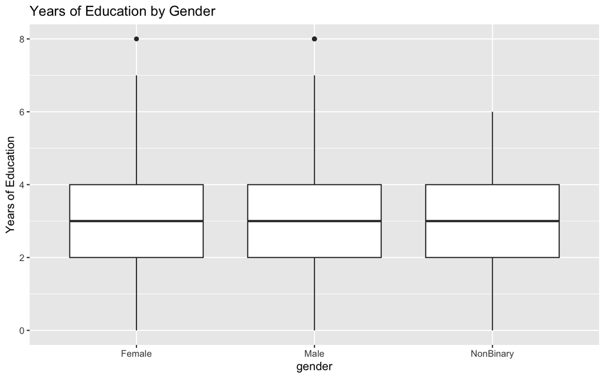

```r
ggplot(data = z) + geom_boxplot(aes(x = gender, y = e)) + ylab("Years of Education") + ggtitle("Years of Education by Gender")
```

## Question 3

Part 1: Use {ggplot} to make scatterplots of height and weight in relation to age.

Height by age:

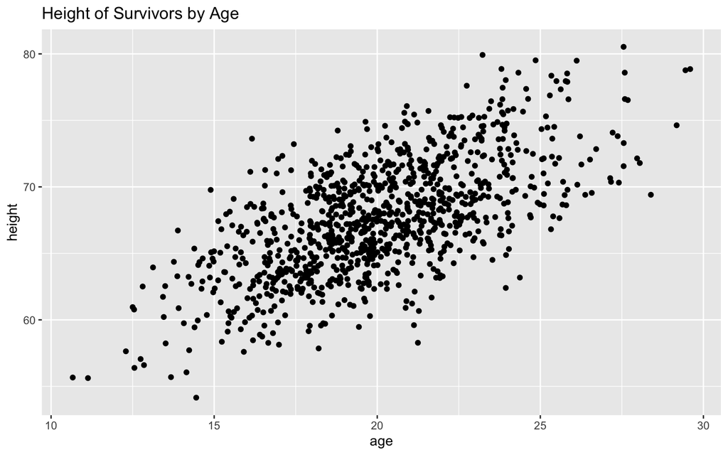

```r
ggplot(data = z) + geom_point(aes(x = age, y = height)) + ggtitle("Height of Survivors by Age")
```

Weight by age:

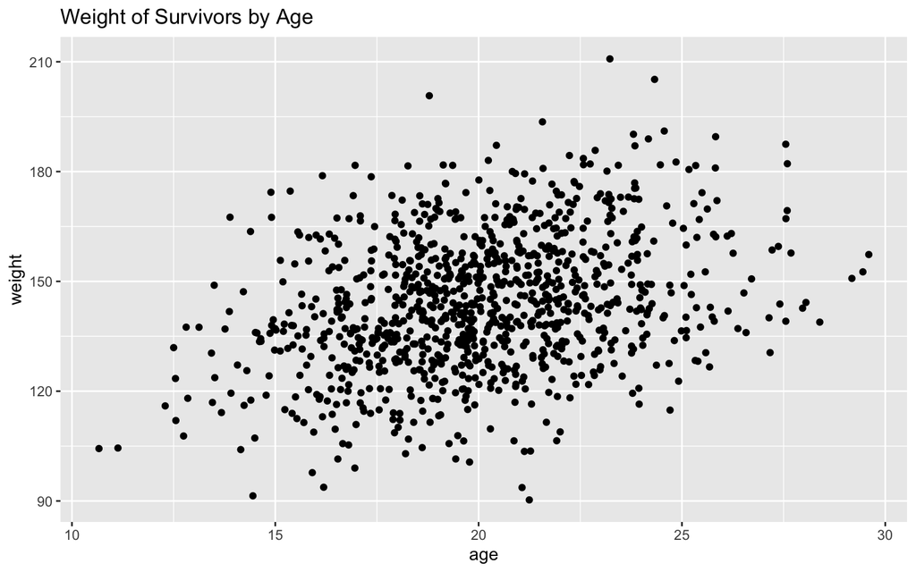

```r
ggplot(data = z) + geom_point(aes(x = age, y = weight)) + ggtitle("Weight of Survivors by Age")
```

Part 2: Do these variables seem to be related? In what way?

Weight and age do not seem to be relates significantly as the points are pretty scattered with little cluster. There does seem to be a slight positive association in which higher weights are associates with older individuals. Height and age also has a lot of scatter but has a tighter association. It suggests that height increases with higher age, which makes sense as the ages are between 10 and 30, thus growth is a factor.

## Question 4

Using histograms and Q-Q plots, check whether the quantitative variables seem to be drawn from a normal distribution. Which seem to be and which do not (hint: not all are drawn from the normal distribution)? For those that are not normal, can you determine from which common distribution they are drawn?

Is age normal? Q-Q plot

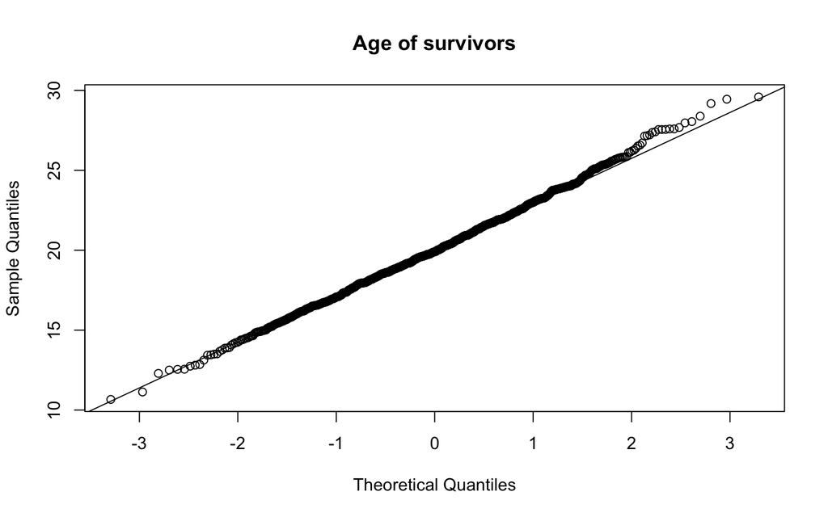

```r
qqnorm(a, main = "Age of survivors")
qqline(a)
```

Histogram

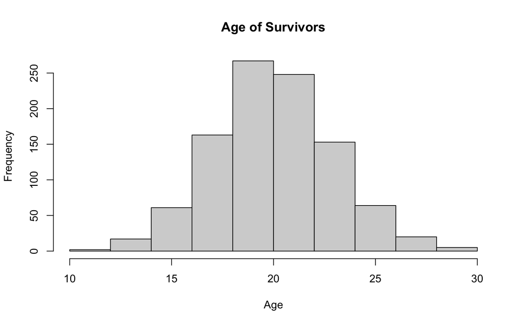

```r
hist(a, main= "Age of Survivors", xlab = "Age")
```

Based on the Q-Q plot and histogram, age appears normal.

Is height normal? Q-Q plot

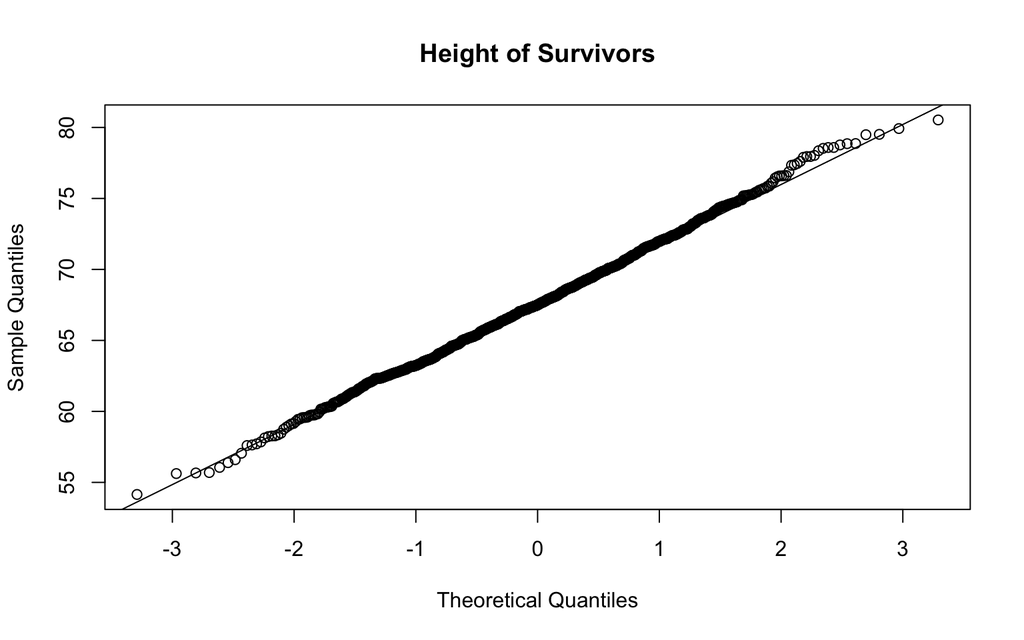

```r
qqnorm(h, main = "Height of Survivors")
qqline(h)
```

Histogram

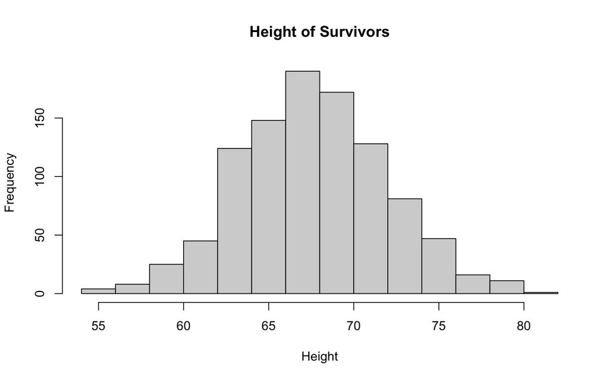

```r
hist(h, main= "Height of Survivors", xlab = "Height")
```

Height also seems normal.

Is weight normal? Q-Q plot

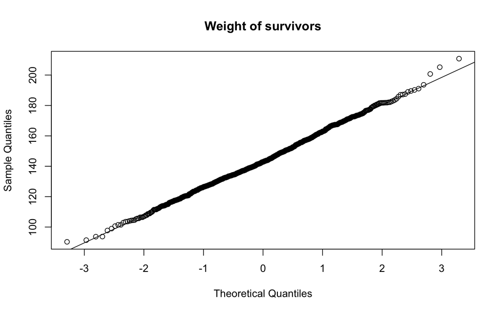

```r
qqnorm(w, main = "Weight of survivors")
qqline(w)
```

Histogram

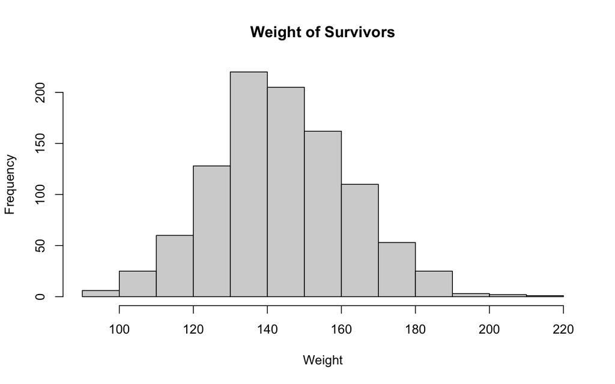

```r
hist(w, main= "Weight of Survivors", xlab = "Weight")
```

Weight seems close to normally distributed, though there is a slight skew towards heavier weights.

Is the number of zombies killed normally distributed? Q-Q plot

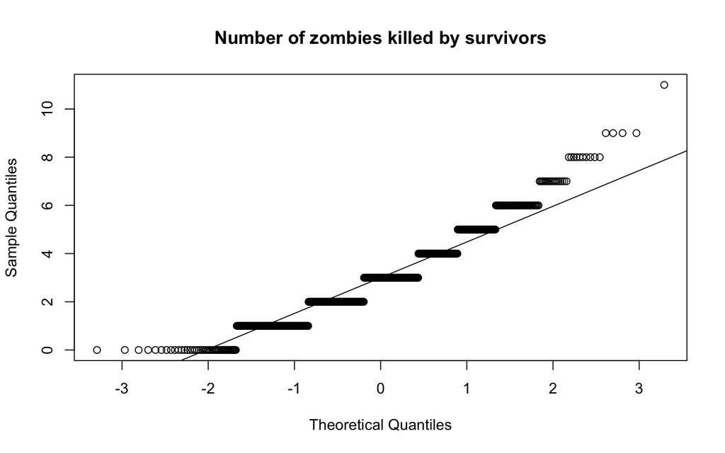

```r
qqnorm(zk, main = "Number of zombies killed by survivors")
qqline(zk)
```

Histogram

[figure not shown]

```r
hist(a, main= "Number of zombies killed by survivors", xlab = "Number of zombies killed")
```

This Q-Q plot does not look normally distributed. This could be a poisson distribution as it’s a count.

Is years of education normally distributed? Q-Q plot

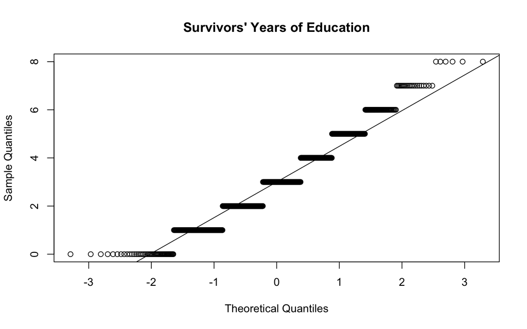

```r
qqnorm(e, main = "Survivors' Years of Education")
qqline(e)
```

Histogram

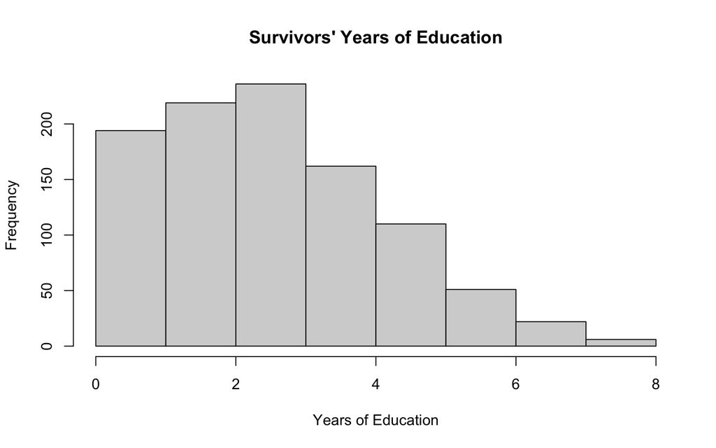

```r
hist(e, main= "Survivors' Years of Education", xlab = "Years of Education")
```

Years of education does not look normally distributed in either Q-Q plot or histogram. I think this might also be a poisson distribution since the Q-Q plot looks like the previous.

## Question 5

Now use the sample() function to sample ONE subset of 30 zombie survivors (without replacement) from this population and calculate the mean and sample standard deviation for each variable. Also estimate the standard error for each variable, and construct the 95% confidence interval for each mean. Note that for the variables that are not drawn from the normal distribution, you may need to base your estimate of the CIs on slightly different code than for the normal…

First, create the sample

```r
n<-30
set.seed(923)
sam1<-sample_n(z, size = n, replace = FALSE) #had to use sample_n to make this work
```

Then, calculate means for each variable Sample age mean

```r
mean(sam1$age)
```

```
## [1] 20.66272
```

Sample height mean

```r
mean(sam1$height)
```

```
## [1] 69.10282
```

Sample weight mean

```r
mean(sam1$weight)
```

```
## [1] 148.1069
```

Sample number of zombies killed mean

```r
mean(sam1$zombies_killed)
```

```
## [1] 2.533333
```

Sample years of education mean

```r
mean(sam1$years_of_education)
```

```
## [1] 3.5
```

And calculate standard deviations - ((I think I should use sd() since this is a sample?)) Sd of sample age

```r
sd(sam1$age)
```

```
## [1] 2.870268
```

sd of sample height

```r
sd(sam1$height)
```

```
## [1] 4.436441
```

sd of sample weight

```r
sd(sam1$weight)
```

```
## [1] 17.99827
```

sd of sample’s number of zombies killed

```r
sd(sam1$zombies_killed)
```

```
## [1] 1.676065
```

sd of sample’s years of educations

```r
sd(sam1$years_of_education)
```

```
## [1] 1.77628
```

Sample age standard error

```r
sd(sam1$age)/mean(sam1$age)
```

```
## [1] 0.1389104
```

Sample height standard error

```r
sd(sam1$height)/mean(sam1$height)
```

```
## [1] 0.06420058
```

Sample weight standard error

```r
sd(sam1$weight)/mean(sam1$weight)
```

```
## [1] 0.1215222
```

Sample number of zombies killed standard error

```r
sd(sam1$zombies_killed)/mean(sam1$zombies_killed)
```

```
## [1] 0.6616048
```

Sample’s years of education standard error

```r
sd(sam1$years_of_education)/mean(sam1$years_of_education)
```

```
## [1] 0.5075087
```

Lastly, confidence intervals:

Sample Age confidence interval

```r
am<-mean(sam1$age)
asd<-sd(sam1$age)
aupper <- am + qnorm(0.975, mean = am, sd = asd) * (sd(sam1$age)/mean(sam1$age)) #qnorm because age was normally distributed
alower <- am + qnorm(0.025, mean = am, sd = asd) * (sd(sam1$age)/mean(sam1$age))
aci <- c(alower, aupper)
aci
```

```
## [1] 22.75153 24.31445
```

Sample height confidence interval

```r
hm<-mean(sam1$height)
hsd<-sd(sam1$height)
hupper <- hm + qnorm(0.975, mean = hm, sd = hsd) * (sd(sam1$height)/mean(sam1$height)) #qnorm because height was normally distributed
hlower <- hm + qnorm(0.025, mean = hm, sd = hsd) * (sd(sam1$height)/mean(sam1$height))
hci <- c(hlower, hupper)
hci
```

```
## [1] 72.98102 74.09750
```

Sample weight confidence interval

```r
wm<-mean(sam1$weight)
wsd<-sd(sam1$weight)
wupper <- wm + qnorm(0.975, mean = wm, sd = wsd) * (sd(sam1$weight)/mean(sam1$weight)) #qnorm because weight was normally distributed
wlower <- hm + qnorm(0.025, mean = wm, sd = wsd) * (sd(sam1$weight)/mean(sam1$weight))
wci <- c(wlower, wupper)
wci
```

```
## [1]  82.81428 170.39197
```

Sample number of zombies killed confidence interval

```r
zkm<-mean(sam1$zombies_killed)
zkupper <- zkm + qpois(0.975, lambda = zkm, lower.tail = TRUE) * (sd(sam1$zombies_killed)/mean(sam1$zombies_killed)) #qpois because zombies killed was a poisson distribution #lambda is same as mean
zklower <- zkm + qpois(0.025, lambda = zkm, lower.tail = TRUE) * (sd(sam1$zombies_killed)/mean(sam1$zombies_killed))
zkci <- c(zklower, zkupper)
zkci
```

```
## [1] 2.533333 6.502962
```

Sample’s years of education confidence interval

```r
em<-mean(sam1$years_of_education)
eupper <- em + qpois(0.975, lambda = em, lower.tail = TRUE) * (sd(sam1$years_of_education)/mean(sam1$years_of_education)) #qpois because years of education  was a poisson distribution #lambda is same as mean
elower <- em + qpois(0.025, lambda = em, lower.tail = TRUE) * (sd(sam1$years_of_education)/mean(sam1$years_of_education))
eci <- c(elower, eupper)
eci
```

```
## [1] 3.50000 7.56007
```

## Question 6

Now draw 99 more random samples of 30 zombie apocalypse survivors, and calculate the mean for each variable for each of these samples. Together with the first sample you drew, you now have a set of 100 means for each variable (each based on 30 observations), which constitutes a sampling distribution for each variable. What are the means and standard deviations of this distribution of means for each variable? How do the standard deviations of means compare to the standard errors estimated in [5]? What do these sampling distributions look like (a graph might help here)? Are they normally distributed? What about for those variables that you concluded were not originally drawn from a normal distribution?

Drawing 99 more samples

```r
k <- 99 # number of samples
n2 <- 30 # size of each sample
set.seed(923)
sam2<-NULL
for (i in 1:k) {
    sam2[[i]] <- sample_n(z, size = n2, replace = FALSE)
}
```

Adding the first sample to the list:

```r
sam3<-c(list(sam2), sam1)
```

I CANNOT FOR THE LIFE OF ME FIGURE OUT HOW TO SELECT INDIVIDUAL VARIABLES TO TAKE THE MEANS and figure out sampling distributions

I’ve tried, select() but that doesn’t work, tried subset(), filter() is no lists, even downloaded a package specifically for lists but that didn’t help

Any ideas? I’m also going to office hours on Monday, I can ask

## Challenges

1. The sample() function didn’t work for me, it kept giving me an NA message. After googling, I ended up using sample_n() from dplyr which might not be a great solution because it’s been superseded by a new function. So, it might just break on me one day and not get fixed.
2. I found deciding which distribution the variables were terribly tricky. I went back and forth on my answers several times obviously based on the graphs but also trying to make the confidence intervals made me realize I wasn’t using the right distribution for one of them (I think anyway). 3)I always find it annoying trying to decide which equations to just run and which to save as variables. I sometimes think it might be easier to save but then you have to remember them and constantly come up with unique names. On the other hand, I often noticed when the next equations were building on previous equations it might have been more efficient to save them, but, at the same time, they were short enough to just re-run. I don’t know, it’s a delicate balance to me.
3. I found the last two questions really difficult, I’m totally stuck on the last one. I wish they were combined because trying to figure out how to combined the original sample with the other 99 was really tough and took a lot of googling and trial and error (and I’m still not sure it’s right).
4. I had so many issues upon first knit, of course. Literally just uploading the file was being really difficult because I tend to use file.choose() but it doesn’t knit so then I switched to curl but the url wasnt’t working at all. After banging (clicking) around for awhile, I realized i was forgetting to click raw before copying the url. I also had to add my packages at the top.